# Feature Selection and Predictive Performance in Incomplete, Higher-Dimensional Datasets

Scenario 38: Simulate Datasets

## Initial Setup

Load relevant packages and set a seed.

```r
packs = c("caret","corrplot","dplyr","ggplot2","lmf","mvtnorm","reshape2")
lapply(packs, require, character.only = TRUE)
set.seed(103871)
```

## Create Scenario Datasets

**corr = mixed-high, p = 60, Complete Cases = 25%**  
Each scenario consists of 100 simulated datasets. 400 observations are simulated and split in half to produce training and testing datasets. For this scenario, the supervisor is continuous and is determined by: Y = *X*$\beta$ + $\epsilon$, where *X* is a matrix of multivariate normal random variables with a mixed-high level of correlation (mean of .3 for most features with some features having a higher pairwise correlation between .75 and .85). The total number of features is 60 and consists of 10 truly associated features and 50 noise features. The first 10 features are the truly associated features. Features 1 through 5 are positively associated with the supervisor and have coefficients of .1, .2, .3, .4 and .5, respectively. Features 6 through 10 have the same coefficient magnitudes but are negatively associated with the supervisor. Complete datasets are first simulated and then missing data is incorporated (see below).

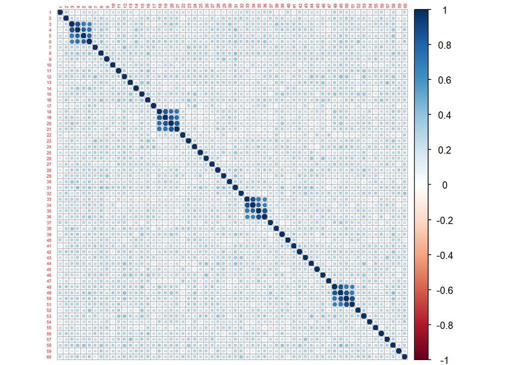

Fig. 1: Correlation plot for 1st sample dataset

```r
scenID        = 38                # scenario no. for tracking and filenames
x             = 1:100             # no. of datasets to create for each scenario
n             = 400               # sample size per dataset before train/test split
p             = 60                # scenario dependent (35,60,110,210,260)
mu            = rep(0,p)
cor           = 0.3               # scenario dependent, initial level

Sigma         = matrix(rnorm(p*p, mean = 0.3, sd = 0.025), nrow = p, ncol = p)
diag(Sigma)   = 1

# Add highly correlated predictors
highCorrInd   = seq(3,p,15)
for (i in 1:length(highCorrInd)) {
  for (j in 0:2) {
   Sigma[highCorrInd[i]+j,highCorrInd[i]+j+1] = rnorm(1, mean = 0.85, sd = 0.02)}
  for (k in 0:1) {
   Sigma[highCorrInd[i]+k,highCorrInd[i]+k+2] = rnorm(1, mean = 0.75, sd = 0.02)}
  Sigma[highCorrInd[i],highCorrInd[i]+3] = rnorm(1, mean = 0.70, sd = 0.02)
}

Sigma[lower.tri(Sigma)] = t(Sigma)[lower.tri(Sigma)]
Sigma2        = nearPD(Sigma, corr = TRUE, keepDiag = TRUE)  # ensure matrix is pos. semidefinite

matFunc       = function(x) {rmvnorm(n,mu,Sigma2)}
compDataSet   = lapply(x,matFunc)
corrplot(cor(compDataSet[[1]]), tl.cex = 0.35)
```

**Generate Supervisor Value Y and append to complete datasets**

```r
supVect             = c(.1,.2,.3,.4,.5,-.1,-.2,-.3,-.4,-.5,rep(0,p-10))
supFunc             = function(x) {x%*%supVect+rnorm(1)}

for (i in 1:length(x)){
   y = apply(compDataSet[[i]], 1, supFunc)
   compDataSet[[i]] = cbind(compDataSet[[i]],y)
}

names(compDataSet)  = paste0("CompMatrix", 1:length(x))
```

```r
missMatricesPrelim  = missMatricesFinal = vector("list", length(x))
for (i in 1:length(x)){
   missMatricesPrelim[[i]] = matrix(rbinom(n*(p-5+1), size = 1, .983), n, p-5+1)   # prob of nonmissing, change by scenario
   missMatricesPrelim[[i]][missMatricesPrelim[[i]]==0] = NA
}

compVect = rep(1,n)

for (i in 1:length(x)){
  marVect1prob = 1-(1/(1+exp(-compDataSet[[i]][,1]-compDataSet[[i]][,6]+2)))  # MAR for predictor 5
  marVect1 = rbinom(n, size=1, prob = marVect1prob)
  marVect1[marVect1==0] = NA
  # Predictor 10 is MAR with components of x1 and x6
  marVect2prob = 1-(1/(1+exp(compDataSet[[i]][,1]+0.5*compDataSet[[i]][,6]+2)))
  marVect2 = rbinom(n, size=1, prob = marVect2prob)
  marVect2[marVect2==0] = NA
# combine genereated vectors
  missMatricesFinal[[i]] = cbind(compVect, missMatricesPrelim[[i]][,1:3],marVect1,compVect ,missMatricesPrelim[[i]][,4:6],marVect2,missMatricesPrelim[[i]][,7:(p-4)],compVect)
}
# add predictor labels
names(missMatricesFinal) = paste0("missMatrix", 1:length(x))
```

**Create Missing Datasets**

```r
missDataSet = vector("list", length(x))
for (i in 1:length(x)){
  missDataSet[[i]] = compDataSet[[i]]*missMatricesFinal[[i]]
}
```

**Split into Training and Test Datasets**  
Use 50%/50% training test split.

```r
testMatrix = trainMatrix = matrix(0, nrow=length(x), ncol=200)
for (i in 1:length(x)){
  vect1            = sample(1:400, 200, replace = FALSE)
  trainMatrix[i,]   = vect1
  testMatrix[i,]  = (1:400)[-vect1]
}

trainDataSet = testDataSet = vector("list", length(x))
for (i in 1:length(x)){
  trainDataSet[[i]] = missDataSet[[i]][trainMatrix[1,],]
  testDataSet[[i]]  = missDataSet[[i]][testMatrix[1,],]
}
```

**Check Percentage of Complete Observations (and Missing Percentage)**

```r
ccFunc = function(x){as.numeric(summary(complete.cases(x))[3])}
nonMissingTrain = unlist(lapply(trainDataSet,ccFunc))
nonMissingTest = unlist(lapply(testDataSet,ccFunc))
```

Avg. % of Training Data Rows with Non Missing Values (complete cases): **23.8**  
Avg. % of Test Data Rows with Non Missing Values (complete cases): **24.86**

**Graphical Depiction of Missing Data - Dataset 1**  
A visual depiction of the missing features is shown below for one of the simulated training datasets. Lines in black indicate that the feature is missing for that observation. Features 5 and 10 contain a significant amount of missing data.

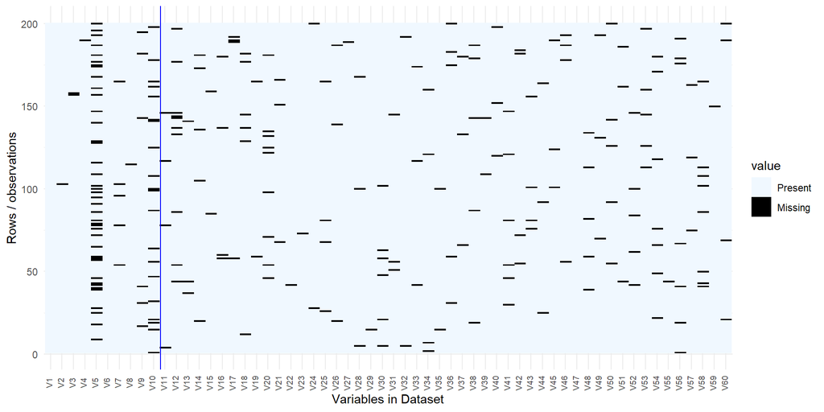

Fig. 2: Missing Data Plot for 1st Training Dataset

```r
ggplot_missing <- function(x){
  x %>% is.na %>% melt %>%
    ggplot(data = ., aes(x = Var2, y = Var1)) +
    geom_raster(aes(fill = value)) +
    scale_fill_manual(values = c("aliceblue","black"),labels = c("Present","Missing"))+
    theme_minimal() +
    theme(axis.text.x  = element_text(angle=90, vjust=0.25, size = 7)) +
    geom_vline(xintercept = 10.6, col = "blue") +
    labs(x = "Variables in Dataset", y = "Rows / observations")
}
ggplot_missing(as.data.frame(trainDataSet[[1]])[,1:p])
```

## Save Datasets

Datasets are saved to be used by each of the 4 methods.

```r
save(compDataSet, file = paste0("compDataSet",scenID,".Rdata"))
save(missMatricesFinal, file = paste0("missMatricesFinal",scenID,".Rdata"))
save(missDataSet, file =paste0("missDataSet",scenID,".Rdata"))
save(trainDataSet, file = paste0("trainDataSet",scenID,".Rdata"))
save(testDataSet, file = paste0("testDataSet",scenID,".Rdata"))
```